# Google Maps Report

paul

March 8, 2017

# Data Extraction from Google Maps API:

### Overview:

- The [Google Web Services API](https://developers.google.com/maps/web-services/overview) is divided into multiple subsequent APIs each responsible for offering unique features.
  - *Directions:* calculates directions between locations in an optimized manner.
  - *Distance Matrix:* provides travel distance and time for origin and destination pairs.
  - *Elevation:* provides elevation data for points.
  - *Geocoding:* provides geocoding and reverse geocoding. From address to lat/lng pairs and vice versa.
  - *Roads:* snaps points of travel to closest road, speed limits, tracking(only for premium).
  - *Time Zone:* provides time zone information about a location.
  - *Places:* Extracts and returns points of interest around a center.
- **Please refer to the developer documentation for each webservice API under the *“developer’s guide”* option. Google does an amazing job explaining the full functionality of each webservice and provides ample examples.**
  - Interesting features often includes *biasing* of search results to favor conditions met by parameters.
  - It is relatively easy to extract information for a list of points by seperating via *“|”* or *“,”*.
- All API requests can be made using a **HTTP GET** request.
  - Example format: `https:maps.googleapis.com/maps/api/{API Service Name}/{return format: json or xml}/{query}`
  - Example request example: `https://maps.googleapis.com/maps/api/directions/json?origin=Disneyland&destination=Universal+Studios+Hollywood4&key=YOUR_API_KEY`
- An access key is required and there are quotas restricting access.
- An [premium account](https://developers.google.com/maps/premium/usage-limits) is available for purchase which allows access to more functionality and more quota. However, the free access keys are sufficient for most purposes.
- Similar to other APIs, each object in Google Maps also includes its own Id and this Id is often used to request more detailed information via */detail/* feature compared to just using the name of the object.

### Creating Access Key:

#### Test Email Account Information:

- *Name:* API-Testing(first name) NRC(last name)
- *Username/Email:* NRC.API.Testing@gmail.com
- *Password:* NRCTesting123
- *Birthday:* July 1st 1997
- *Gender*: Rather not say

#### Steps to Create Key:

1: Log into the [Google API Console](https://console.developers.google.com).

2: In the top menu bar, click create “new project”.

[figure not shown]

3: Enable the following permissions under the *“dashboard”*.

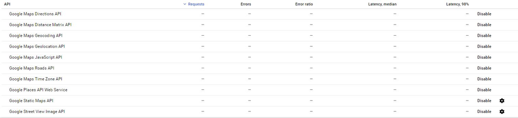

4: On the left menu, select *Credentials* and click *Create Credentials*. The information under the *key* is the credential used to access the maps api.

[figure not shown]

### Sample Queries and Extracting Data:

- It is recommanded to first test out the query in a web browser
- The main packages used are as follows and are available for download on CRAN through *install.packages*:
  - [httr](https://cran.r-project.org/web/packages/httr/vignettes/quickstart.html) to make HTTP requests.
    - [httr documentation](https://cran.r-project.org/web/packages/httr/httr.pdf)
  - [jsonlite](https://cran.r-project.org/web/packages/jsonlite/vignettes/json-aaquickstart.html) to parse JSON data.

```r
    library(httr);
    library(jsonlite);
```

```r
    key = "AIzaSyBGTs-gZCbyP8n0Hvw_VZ76Z6YrST1DNa8"
    host = "https://maps.googleapis.com/maps/api"

    ## Extracting location information about NRC library in Ottawa
    request1 = paste(host,"/geocode/json", "?address=NRC+National+Science+Library&key="
                     ,key,sep="")

    raw1 = GET(request1)


    ## Note the actual response data is located under the content information
    ## and that the content is in raw format.
    names(raw1)
```

```
##  [1] "url"         "status_code" "headers"     "all_headers" "cookies"
##  [6] "content"     "date"        "times"       "request"     "handle"
```

```r
    ##  Parsing into JSON nested lists/data frames
    response = jsonlite::fromJSON(content(raw1,"text"))
    paste("formatted address",response$results$formatted_address,sep=" ");
```

```
## [1] "formatted address 1200 Montreal Rd, Ottawa, ON K1A 0R6, Canada"
```

```r
    ##  Then the data needs to be parsed,which will not be shown. It is recommanded to use
    ##  the str() function to investigate nesting.
```

### First Thoughts:

- Google Maps API does an amazing job reporting geographical location and makes it easy to access the data. The main diffculty will be parsing the JSON/XML response from the sever.
- It is recommanded to use Google Maps API to supplment existing geographical data to perform analysis. It will be more useful to use google Maps to provide visualizations within R.

### Next Steps:

- More time will be spent exploring other packages that provides calculation and spatial analysis techniques.

# Visualizing:

### Overview:

- There are many packages in R to help with with visualization of geographical location data. The following is a few of the useful packages:
  - *[ggplot2](http://ggplot2.org/):* provides an interface to simplify plotting of data and helps to visualize geographical data.
  - *[tmap](https://cran.r-project.org/web/packages/tmap/vignettes/tmap-nutshell.html):* Allows flexible and interactive functions to produce thematic maps.
  - *[ggmap](https://blog.dominodatalab.com/geographic-visualization-with-rs-ggmaps/):* Provides an easy way to overlay static maps from google Maps and other sites to visualize data.
  - *[leaflet](https://rstudio.github.io/leaflet/):* R version of the popular JavaScript library. This is used to create interactive maps.
  - *[SP Package](https://cran.r-project.org/web/packages/sp/vignettes/intro_sp.pdf):* This package is one of the foundational packages in R that deals with spatial data. It was observed that many of of the packages references back to the SP package.

### Leaflet:

- The Visualization section of the report will mainly focus on using the leaflet pacakge. It appears that leaflet pacakge offers the most flexibility and customizability for visualization.
- Since this package works with html and javascript in it’s underlying structure. The interactive maps can not be displayed in PDF format.

#### Example 1: Online Tutorial

- [Introduction videos to Leaflet](https://www.youtube.com/watch?v=ktWjjAlAKtE)

```r
    rm(list = ls());

    library(leaflet)
```

```r
    ## "leaflet()" essentially initializes a window to display the map
    ## addTiles() allows placing layers
    mymap = leaflet() %>%
        addTiles()


    ## Use tile providers to include custom map types
    mymap = addProviderTiles(mymap,provider="OpenStreetMap.Mapnik")
    mymap
```

[interactive chart not shown]

* **[Preview of Other Map Providers](https://leaflet-extras.github.io/leaflet-providers/preview/)**

```r
    ## Seting view and adding markers

    taj_Mahal_Lat = 27.1750
    taj_Mahal_Lng = 78.0419
    ## SetView allows you to set view based on a center coordinate
    mymap = setView(mymap, lng=taj_Mahal_Lng, lat=taj_Mahal_Lat, zoom=15)

    ## Adding a marker at Taj Mahal
    mymap = addMarkers(mymap,lng=taj_Mahal_Lng,lat=taj_Mahal_Lat,
                       popup="Taj Mahal")
    mymap
```

[interactive chart not shown]

```r
    rm(list = ls())
```

- [SP package](https://cran.r-project.org/web/packages/sp/vignettes/intro_sp.pdf)

### Example 2: Showing Some Google Map Outputs:

- **Goal: Tracing the directions from Work to an apartment, showing places of interest around these locations with appropriate labels.**

#### Functions

- [Polyline](https://developers.google.com/maps/documentation/utilities/polylinealgorithm)
- Rather useful for unpacking JSON object [tidyjson](https://cran.r-project.org/web/packages/tidyjson/vignettes/introduction-to-tidyjson.html)
- More easily understood in terms of code:
  - everytime a nested list is “entered”, the arrarys needs to be stacked
  - This is useful if the nest list has multiple elements with the same names. However for single and small bits of information, direct subseting using “[[]]” will be the easiest.

```r
    extracting_Origin_End = function(response_Text)
{
    require(tidyjson)
    require(dplyr)


    ## The following can be reduced down a loop. It is kept as it is
    ## To reflect the structure of the JSON response

    # Extracting direction markers for start:
    directions_Markers_Start =response_Text %>% as.tbl_json %>%
        enter_object("routes") %>% gather_array %>%
        enter_object("legs") %>% gather_array %>%
        spread_values(
            address = jstring("start_address")
        ) %>% enter_object("start_location")%>%
        spread_values(
            lat = jnumber("lat"),
            lng = jnumber("lng")
        ) %>% select(address, lat,lng)%>%
        tbl_df

    directions_Markers_End = response_Text %>% as.tbl_json %>%
        enter_object("routes") %>% gather_array %>%
        enter_object("legs") %>% gather_array %>%
        spread_values(
            address = jstring("end_address")
        ) %>% enter_object("end_location")%>%
        spread_values(
            lat = jnumber("lat"),
            lng = jnumber("lng")
        ) %>% select(address, lat,lng)%>%
        tbl_df


    directions_Markers = rbind(directions_Markers_Start,directions_Markers_End)
    return(directions_Markers)
}
```

- Decoding Polyline Function borrowed:

```r
# Custom decode function
# Taken from http://s4rdd.blogspot.com
# /2012/12/google-maps-api-decoding-polylines-for.html

decodeLine <- function(encoded){
  require(bitops)

  vlen <- nchar(encoded)
  vindex <- 0
  varray <- NULL
  vlat <- 0
  vlng <- 0

  while(vindex < vlen){
    vb <- NULL
    vshift <- 0
    vresult <- 0
    repeat{
      if(vindex + 1 <= vlen){
        vindex <- vindex + 1
        vb <- as.integer(charToRaw(substr(encoded, vindex, vindex))) - 63
      }

      vresult <- bitOr(vresult, bitShiftL(bitAnd(vb, 31), vshift))
      vshift <- vshift + 5
      if(vb < 32) break
    }

    dlat <- ifelse(
      bitAnd(vresult, 1)
      , -(bitShiftR(vresult, 1)+1)
      , bitShiftR(vresult, 1)
    )
    vlat <- vlat + dlat

    vshift <- 0
    vresult <- 0
    repeat{
      if(vindex + 1 <= vlen) {
        vindex <- vindex+1
        vb <- as.integer(charToRaw(substr(encoded, vindex, vindex))) - 63
      }

      vresult <- bitOr(vresult, bitShiftL(bitAnd(vb, 31), vshift))
      vshift <- vshift + 5
      if(vb < 32) break
    }

    dlng <- ifelse(
      bitAnd(vresult, 1)
      , -(bitShiftR(vresult, 1)+1)
      , bitShiftR(vresult, 1)
    )
    vlng <- vlng + dlng

    varray <- rbind(varray, c(vlat * 1e-5, vlng * 1e-5))
  }
  coords <- data.frame(varray)
  names(coords) <- c("lat", "lon")
  coords
}
```

#### Main Example:

```r
 # Libraries:
    library(leaflet)
    library(httr)
    library(jsonlite)
    library(tidyjson)
    library(dplyr)
    library(bitops)
```

```r
    # Setting up Directions requests:
    apartment_Address = "147+Millgreen+Crescent,+Gloucester"
    work_Address = "M-50,+1200+Montreal+Rd,+Ottawa,+ON+K1A+0R6"
    api_Key = "AIzaSyBGTs-gZCbyP8n0Hvw_VZ76Z6YrST1DNa8"
    host = "https://maps.googleapis.com/maps/api"

    directions_Request = paste(host, "/directions/json","?origin=",work_Address,
                               "&destination=",apartment_Address,"&mode=walking",
                               "&key=",api_Key,sep = "")

    # Extracting directions data
    raw = GET(directions_Request)

    directions_Response = jsonlite::fromJSON(
        content(raw,"text")
    )


    # Parsing route information
    directions_Markers = extracting_Origin_End(content(raw,"text"))
        ## The route will be a rough polyline
        ## extracted from the "overViewPolyline"
    route = decodeLine(
        directions_Response$routes$overview_polyline[["points"]]
    )

    ## The main diffculty is that you have to know JSON format
    ## and thus it will take trials to parse the information.
    ## which is why it is easier to use tidyJson
    route_Information = data.frame(
        distance = directions_Response$routes$legs
        [[1]][["distance"]][["text"]],
        duration= directions_Response$routes$legs
        [[1]][["duration"]][["text"]]
    )

     rm(list = c("directions_Request",
                 "raw", "directions_Response"))
```

```r
    #loading basic map.
    example2_Map = leaflet() %>%
        addProviderTiles(provider="OpenStreetMap.Mapnik") %>%
        fitBounds(lng1=directions_Markers$lng[[1]],
                  lat1=directions_Markers$lat[[1]],
                  lng2=directions_Markers$lng[[2]],
                  lat2=directions_Markers$lat[[2]]
                  )

    # Adding Markers:
    example2_Map = example2_Map %>%
        addMarkers(lng=directions_Markers$lng,
                   lat=directions_Markers$lat,
                   label=c("work","home")
        )

    #Adding route information:
    popup_Content = paste(sep = "","distance: ",
                          route_Information$distance,"<br>",
                          "duration: ", route_Information$duration,
                          "<br>")

    example2_Map = example2_Map %>%
        addPolylines( lng=route$lon,
            lat=route$lat,
            popup=popup_Content
        )
```

```r
    # Setting up for URL requests
    work_Lat = directions_Markers$lat[[1]]
    work_Lng = directions_Markers$lng[[1]]
    home_Lat = directions_Markers$lat[[2]]
    home_Lng = directions_Markers$lng[[2]]
    keyword = "point+of+interest"
    ## circular radius in meters
    radius = 2000


    #function to extract rawData:
    place_Raw_data = function(lat, lng, keyword, radius, api_Key)
    {
        request = paste(host,"/place/nearbysearch/json",
        "?location=",lat,",",lng,"&radius=",
        radius,"&keyword=",keyword, "&key=",
        api_Key,sep="")

        raw = jsonlite::fromJSON(content(
                GET(request),"text"
            ))

    }

    # Getting Raw Data
    poi_Work_Raw= place_Raw_data(work_Lat, work_Lng,
                            keyword, radius, api_Key)
    poi_Home_Raw = place_Raw_data(home_Lat, home_Lng,
                            keyword, radius, api_Key)

    # Function to format Raw Data into organized DF:

    organizePlaceDF= function(raw_Data)
    {
        lat_Lng = raw_Data$results$geometry$location
        names = as.vector(unlist(raw_Data$results$name))
        icon = as.vector(unlist(raw_Data$results$icon))
        rating = as.vector(unlist(raw_Data$results$rating))
        organized_Data = cbind(lat_Lng,rating,icon,names)
        organized_Data
    }


    # getting DF
    home_Df = organizePlaceDF(poi_Home_Raw)
    work_Df = organizePlaceDF(poi_Work_Raw)
    place_Df = rbind(home_Df,work_Df)

    #setting up Icons:
    place_Icons <- icons(
      iconUrl = place_Df$icon,
      iconWidth = 20, iconHeight = 20,
      iconAnchorX = 0, iconAnchorY =0
    )

    #setting up label contents:
    content =list()
    for(i in 1:length(place_Df$icon))
    {
        content_Name= paste("name:",
            place_Df$names[[i]],"<br>")

        content_Rating= paste("rating:",
            place_Df$rating[[i]],"<br>")

        content[[i]] =
            paste(content_Name, content_Rating,
                  sep="<br>")

    }


    # adding the loceations onto the map using google Icons
    example2_Map = addMarkers(example2_Map, lat=place_Df$lat,
                    lng=place_Df$lng,icon=place_Icons,
                    popup=as.vector(content))



     example2_Map
```

[interactive chart not shown]

### Example 3: Visualizing Density

_GOAL: The goal is to map the number of crimes in Alabama  
as a percentage of population and display it on the map.__

1: Downloading and Saving Data:

```r
    rm(list = ls())
    require(httr)
    require(dplyr)
    require(leaflet)
    require(jsonlite)

    url = "https://ucr.fbi.gov/crime-in-the-u.s/2013/crime-in-the-u.s.-2013/tables/table-8/table-8-state-cuts/table_8_offenses_known_to_law_enforcement_alabama_by_city_2013.xls/output.xls"
    api_Key = "&key=AIzaSyBGTs-gZCbyP8n0Hvw_VZ76Z6YrST1DNa8"
    host = "https://maps.googleapis.com/maps/api/geocode/json"
    query = "?address="


##  Could not figure out why the file can not be opened.
##  It is manually downloaded and reformated to a
##  excel format.

    crime_Raw_Data = read.csv(file = "./USA_Crime_Data.csv",
                          header=T,stringsAsFactors = F)

    ## Reformatting Df to contain (city,population, total crime number)

    ## Sorting through NA = 0
    for(i in names(select(crime_Raw_Data,
            -(City))))
    {
        list = crime_Raw_Data[,i]
        list = as.numeric(list)
        list[is.na(list)] = 0
        crime_Raw_Data[,i] = list

    }
    numeric_Data = select(
            crime_Raw_Data,
            Violent.crime:Arson3
        )

    ## new data frame
    data = cbind(
        city=crime_Raw_Data$City,
        fraction=( rowSums(numeric_Data)/
            as.numeric(crime_Raw_Data$Population))
    )
    # rm(list = c("numeric_Data","crime_Raw_Data"))
```

```r
    ## function to extract lat and long for a list of cities
    ## in USA
    ##only the first 50 were plotted, it takes quite a while

    ## to retrieve the data otherwise.

     length = 50
     list = data[,"city"][1:length]

     location_Data = lapply(list,function(x){

                 x = gsub(pattern=" ", replacement= "+",
                      x=x)
                 request = paste(host, query, x,
                            ",USA",api_Key,sep="")

                 raw = jsonlite::fromJSON(
                     content(GET(request),"text")
                 )
                raw$results$geometry$location

                ##  The results for 19th element
                ## "Bear creek" returned multiple
                ## elements.Dont know why
        })

   lat = list()
   lng = list()

    ## merging the lat and lng into the data DF
    for(i in 1:length)
    {
        ##just going to ignore the 19th element for now
           lat[[i]]= location_Data[[i]]$lat
            lng[[i]]= location_Data[[i]]$lng

        if(i==19)
        {
            ##Selecting correct lat data
            string = toString(unlist(
                location_Data[[i]]$lat
            ))

            index = regexpr(
                pattern=",",
                text=string
            )

            lat[[i]]=as.numeric(
                substr(
                    string,1,
                    as.numeric(index[1])-1
                )
            )


            ##Selecting correct lng data
            string = toString(unlist(
                location_Data[[i]]$lng
            ))

            index = regexpr(
                pattern=",",
                text=string
            )

            lng[[i]]=as.numeric(
                substr(
                    string,1,
                    as.numeric(index[1])-1
                )
            )


        }
    }
```

```r
    org_Data = cbind(data[1:length,1:2],lat,
            lng)
    org_Data = as.data.frame(org_Data)

     ## Reorganizing data frame to chage class
    org_Data$fraction = as.numeric(org_Data$fraction)
    org_Data$lat = as.numeric(org_Data$lat)
    org_Data$lng = as.numeric(org_Data$lng)


    ##popup labels:
    popup = list()
    for(i in 1:length(org_Data$fraction)){
        precentage = paste("Precentage:",
            signif(org_Data$fraction[[i]],4)*100)

        city = paste("City:",org_Data$city[[i]])

        return = paste(city, precentage,sep="<br>")
        popup[i] = return

    }
```

```r
    ##setting up the Map
    center_Lat = median(org_Data$lat)
    center_Lng = median(org_Data$lng)

    example3_Map = leaflet(data=org_Data) %>%
        addProviderTiles("OpenStreetMap.DE")%>%
        setView(lat=center_Lat,lng=center_Lng,
                zoom = 8)





    ## Adding circle markers proportional to
    ## the fraction.
    radius_Factor = 100000

     example3_Map = example3_Map %>%
         addCircles(lng=org_Data$lng,
             lat=org_Data$lat,
             popup=popup,
             radius = org_Data$fraction*radius_Factor)


        example3_Map
```

[interactive chart not shown]

# Resources: